# Analisis Perilaku Kukang

2023-03-24

## Library

```r
library(readxl)
library(randtests)
```

# Perilaku Kukang

Ingin diketahui perbedaan perilaku Kukang berdasarkan Jenis Kelamin dan kelompok umur, yaitu Jantan, Betina 1, Betina 2 untuk 8 Perilaku Kukang.

Pengujian perbedaan perilaku ini salah satunya dapat menggunakan Uji ANOVA untuk mengetahui apakah ada perbedaan diantara 3 Kelompok Kukang terhadap perilakunya. Kemudian, setelah ANOVA dihasilkan kita perlu mengecek asumsi-asumsi dalam ANOVA, yaitu:

- Asumsi Kenormalan
- Asumsi Kehomogenan Ragam
- Asumsi Amatan Saling Bebas

Asumsi-Asumsi di atar perlu dipenuhi agar kesimpulan dari hasil ANOVA dapat dikatakan valid. Jika terdapat asumsi yang tidak terpenuhi maka dapat menggunakan alternatif uji yaitu Uji Kruskal-Wallis. Terakhir, setelah dipastikan bahwa terdapat perbedaan signifikan dari hasil ANOVA dan Kruskal-Wallis (Jika asumsi tidak terpenuhi) maka dilakukan Uji Tukey untuk melihat pengaruh jenis kelamin mana yang berbeda secara signifikan terhadap perilaku Kukang.

## Waspada

Pemanggilan data:

```r
data.waspada <- read_xlsx("C:/Users/Agsyan M S/Documents/kuliah IPB/Lain-Lain/Data Bang Adi.xlsx", sheet = 2)
head(data.waspada)
```

```
## # A tibble: 6 × 3
##   Observasi Ulangan Respon
##   <chr>       <dbl>  <dbl>
## 1 W1              1      4
## 2 W1              2     10
## 3 W1              3      8
## 4 W1              4      3
## 5 W2              1      6
## 6 W2              2      2
```

### ANOVA

```r
OlahRAL = aov(Respon ~ Observasi, data = data.waspada)
summary(OlahRAL) #Berbeda Signifikan
```

```
##             Df Sum Sq Mean Sq F value  Pr(>F)
## Observasi    2 316.17  158.08   14.71 0.00146 **
## Residuals    9  96.75   10.75
## ---
## Signif. codes:  0 '***' 0.001 '**' 0.01 '*' 0.05 '.' 0.1 ' ' 1
```

### Asumsi kenormalan

H0 : Galat (eror) menyebar normal  
H1 : Galat tidak menyebar normal

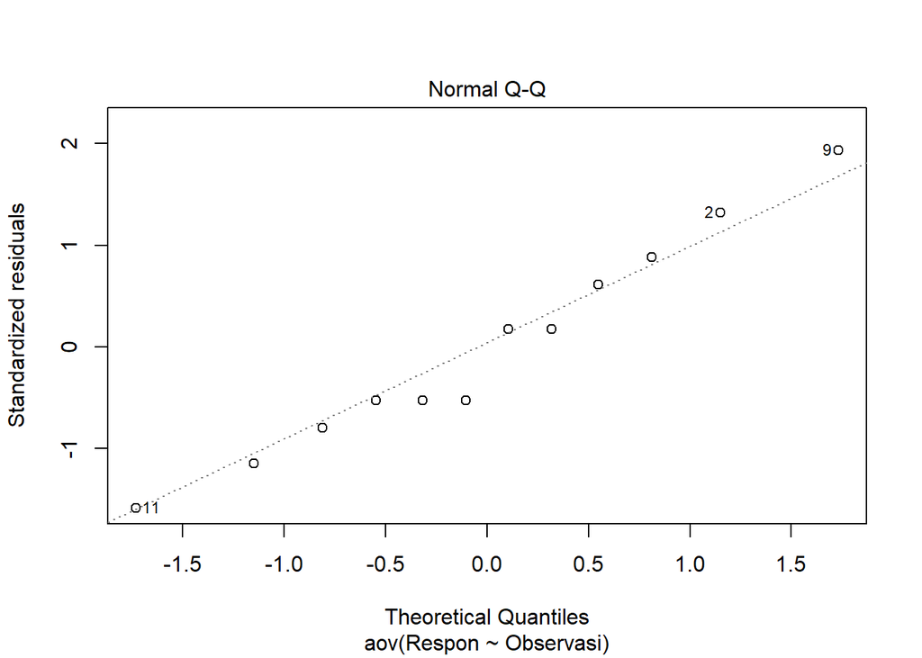

```r
plot(OlahRAL, which = 2)
```

```r
shapiro.test(OlahRAL$residuals) #Tak Tolak H0
```

```
##
##  Shapiro-Wilk normality test
##
## data:  OlahRAL$residuals
## W = 0.96816, p-value = 0.8906
```

Kesimpulan: karena p-value lebih dari 0.05 maka tak tolak H0 atau Galat menyebar normal

### Asumsi Kehomogenan Ragam

H0 : Ragam Homogen  
H1 : Ragam Tak Homogen

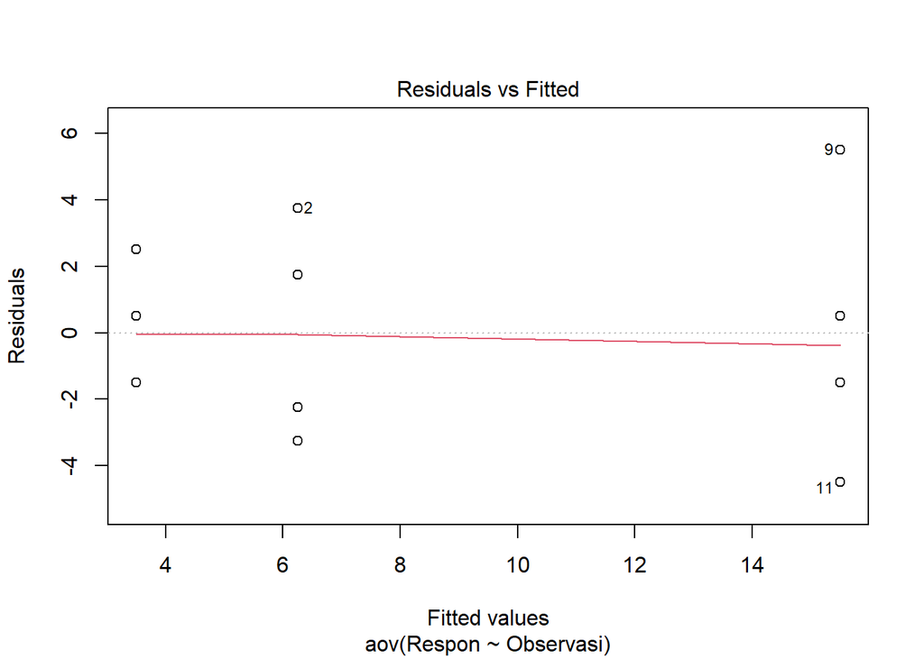

```r
plot(OlahRAL, which = 1)
```

```r
bartlett.test(Respon ~ Observasi, data = data.waspada) #Tak Tolak H0
```

```
##
##  Bartlett test of homogeneity of variances
##
## data:  Respon by Observasi
## Bartlett's K-squared = 1.4723, df = 2, p-value = 0.479
```

Kesimpulan: karena p-value lebih dari 0.05 maka tak tolak H0 atau Ragam homogen.

### Asumsi amatan saling bebas

H0 : Galat saling bebas  
H1 : Galat tidak saling bebas

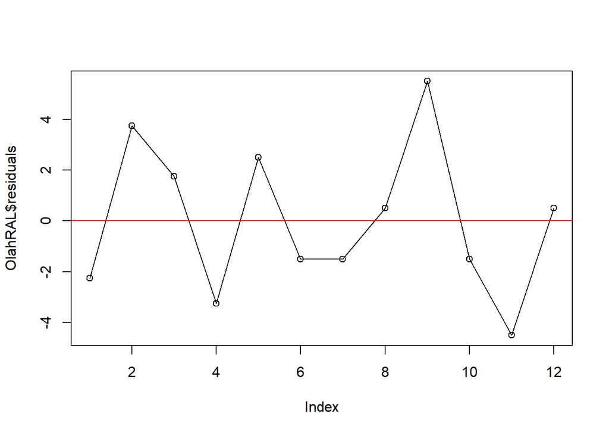

```r
plot(OlahRAL$residuals, type = "o"); abline(h = 0, col = 'red')
```

```r
runs.test(x = OlahRAL$residuals) #Tak Tolak H0
```

```
##
##  Runs Test
##
## data:  OlahRAL$residuals
## statistic = 0.60553, runs = 8, n1 = 6, n2 = 6, n = 12, p-value = 0.5448
## alternative hypothesis: nonrandomness
```

Kesimpulan: karena p-value lebih dari 0.05 maka tak tolak H0 atau Galat saling bebas.

## Mencari Makan

Pemanggilan data:

```r
data.cari.makan <- read_xlsx("C:/Users/Agsyan M S/Documents/kuliah IPB/Lain-Lain/Data Bang Adi.xlsx", sheet = 3)
head(data.cari.makan)
```

```
## # A tibble: 6 × 3
##   Observasi Ulangan Respon
##   <chr>       <dbl>  <dbl>
## 1 MM1             1      3
## 2 MM1             2      1
## 3 MM1             3      2
## 4 MM1             4      8
## 5 MM2             1      2
## 6 MM2             2      5
```

### ANOVA

```r
OlahRAL2 = aov(Respon ~ Observasi, data = data.cari.makan)
summary(OlahRAL2) #Beda Tak Signifikan
```

```
##             Df Sum Sq Mean Sq F value Pr(>F)
## Observasi    2   3.17   1.583   0.294  0.752
## Residuals    9  48.50   5.389
```

#Asumsi kenormalan

H0 : Galat (eror) menyebar normal  
H1 : Galat tidak menyebar normal

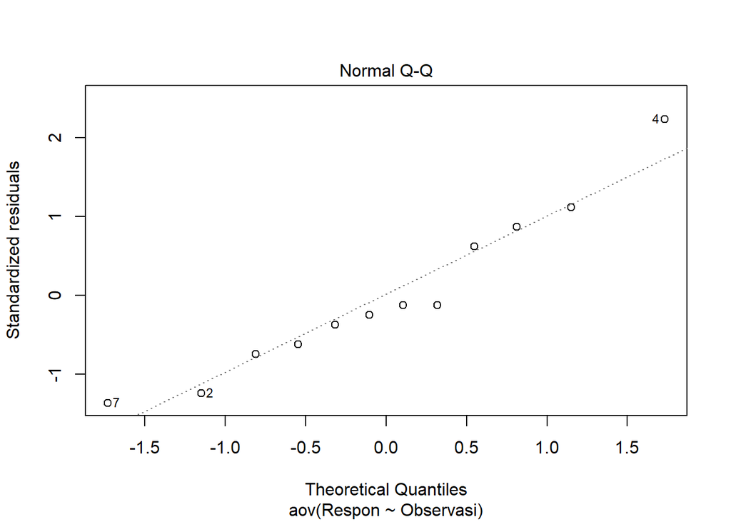

```r
plot(OlahRAL2, which = 2)
```

```r
shapiro.test(OlahRAL2$residuals) #Tak Tolak H0
```

```
##
##  Shapiro-Wilk normality test
##
## data:  OlahRAL2$residuals
## W = 0.94273, p-value = 0.5343
```

H0 : Ragam Homogen  
H1 : Ragam Tak Homogen

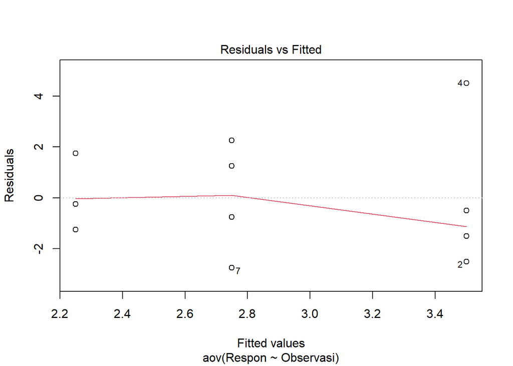

```r
plot(OlahRAL2, which = 1)
```

```r
bartlett.test(Respon ~ Observasi, data = data.cari.makan) #Tak Tolak H0
```

```
##
##  Bartlett test of homogeneity of variances
##
## data:  Respon by Observasi
## Bartlett's K-squared = 1.9131, df = 2, p-value = 0.3842
```

Kesimpulan: Karena p-value > 0.05 maka tak tolak H0 atau ragam homogen.

### Asumsi amatan saling bebas

H0 : Galat saling bebas  
H1 : Galat tidak saling bebas

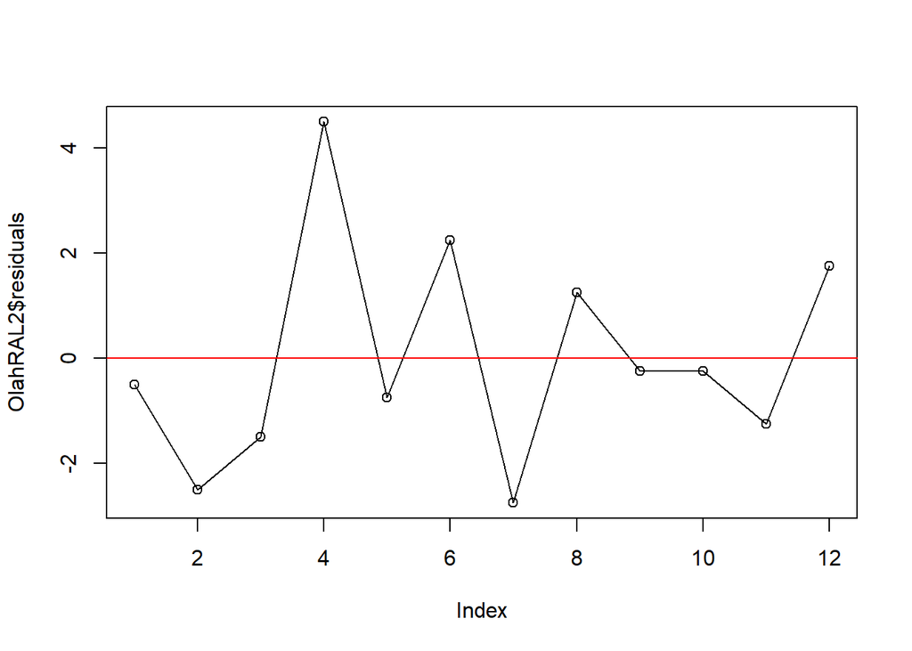

```r
plot(OlahRAL2$residuals, type = "o"); abline(h = 0, col = 'red')
```

```r
runs.test(x = OlahRAL2$residuals) #Tak Tolak H0
```

```
##
##  Runs Test
##
## data:  OlahRAL2$residuals
## statistic = 0.60553, runs = 8, n1 = 6, n2 = 6, n = 12, p-value = 0.5448
## alternative hypothesis: nonrandomness
```

Kesimpulan: karena p-value > 0.05 maka tak tolak H0 atau galat saling bebas

## Makan

Pemanggilan data:

```r
data.makan <- read_xlsx("C:/Users/Agsyan M S/Documents/kuliah IPB/Lain-Lain/Data Bang Adi.xlsx", sheet = 4)
head(data.makan)
```

```
## # A tibble: 6 × 3
##   Observasi Ulangan Respon
##   <chr>       <dbl>  <dbl>
## 1 M1              1      8
## 2 M1              2      2
## 3 M1              3      0
## 4 M1              4      3
## 5 M2              1      1
## 6 M2              2      0
```

### ANOVA

```r
OlahRAL3 = aov(Respon ~ Observasi, data = data.makan)
summary(OlahRAL3) #Beda Tak Signifikan
```

```
##             Df Sum Sq Mean Sq F value Pr(>F)
## Observasi    2  14.00   7.000   1.306  0.318
## Residuals    9  48.25   5.361
```

### Asumsi kenormalan

H0 : Galat (eror) menyebar normal  
H1 : Galat tidak menyebar normal

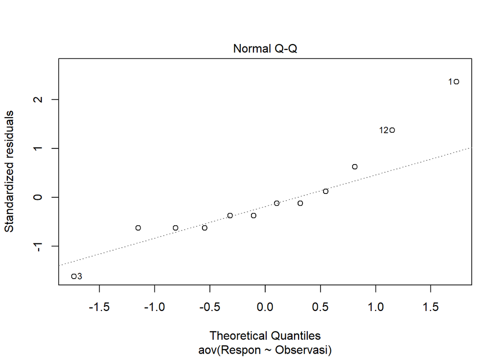

```r
plot(OlahRAL3, which = 2)
```

```r
shapiro.test(OlahRAL3$residuals) #Tak Tolak H0
```

```
##
##  Shapiro-Wilk normality test
##
## data:  OlahRAL3$residuals
## W = 0.90165, p-value = 0.1666
```

Kseimpulan: karena p-value > 0.05 maka tak tolak H0 atau galat menyebar normal.

### Asumsi Kehomogenan Ragam

H0 : Ragam Homogen  
H1 : Ragam Tak Homogen

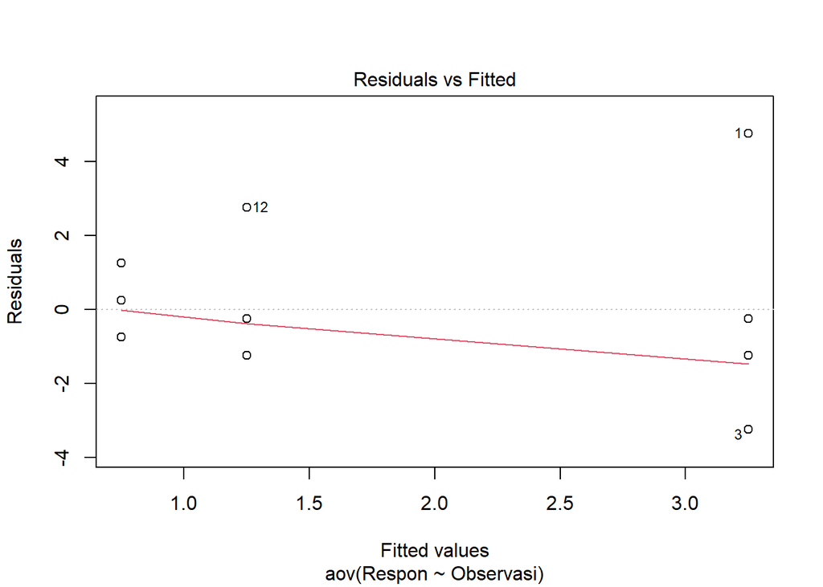

```r
plot(OlahRAL3, which = 1)
```

```r
bartlett.test(Respon ~ Observasi, data = data.makan) #Tak Tolak H0
```

```
##
##  Bartlett test of homogeneity of variances
##
## data:  Respon by Observasi
## Bartlett's K-squared = 3.6546, df = 2, p-value = 0.1608
```

Kesimpulan: karena p-value > 0.05 maka tak tolak H0 atau ragam homogen.

#Asumsi amatan saling bebas

H0 : Galat saling bebas  
H1 : Galat tidak saling bebas

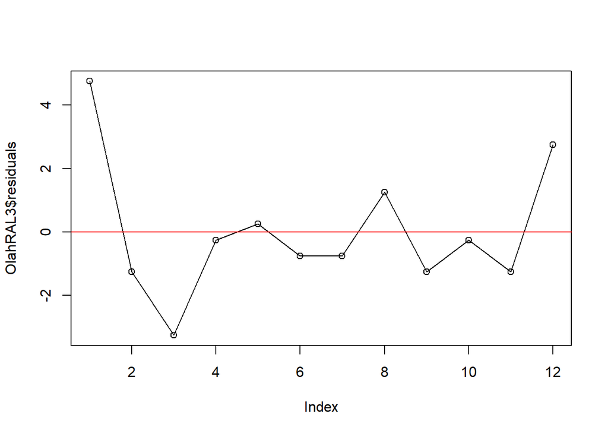

```r
plot(OlahRAL3$residuals, type = "o"); abline(h = 0, col = 'red')
```

```r
runs.test(x = OlahRAL3$residuals) #Tak Tolak H0
```

```
##
##  Runs Test
##
## data:  OlahRAL3$residuals
## statistic = 1.2111, runs = 9, n1 = 6, n2 = 6, n = 12, p-value = 0.2259
## alternative hypothesis: nonrandomness
```

Kesimpulan: karena p-value > 0.05 maka tak tolak H0 atau galat saling bebas.

## Menelisik

Pemanggilan data:

```r
data.menelisik <- read_xlsx("C:/Users/Agsyan M S/Documents/kuliah IPB/Lain-Lain/Data Bang Adi.xlsx", sheet = 5)
head(data.menelisik)
```

```
## # A tibble: 6 × 3
##   Observasi Ulangan Respon
##   <chr>       <dbl>  <dbl>
## 1 Me1             1      2
## 2 Me1             2      0
## 3 Me1             3      0
## 4 Me1             4      2
## 5 Me2             1      2
## 6 Me2             2      7
```

### ANOVA

```r
OlahRAL4 = aov(Respon ~ Observasi, data = data.menelisik)
summary(OlahRAL4) #Beda signifikan
```

```
##             Df Sum Sq Mean Sq F value Pr(>F)
## Observasi    2   73.5   36.75   6.963 0.0149 *
## Residuals    9   47.5    5.28
## ---
## Signif. codes:  0 '***' 0.001 '**' 0.01 '*' 0.05 '.' 0.1 ' ' 1
```

### Asumsi kenormalan

H0 : Galat (eror) menyebar normal  
H1 : Galat tidak menyebar normal

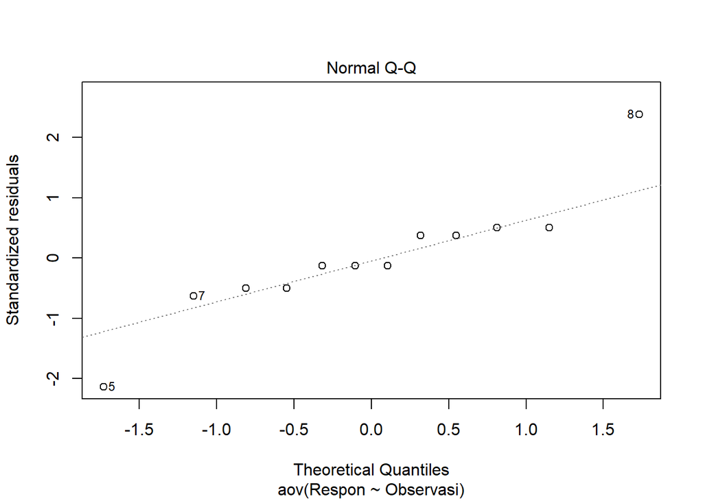

```r
plot(OlahRAL4, which = 2)
```

```r
shapiro.test(OlahRAL4$residuals) #Tak Tolak H0
```

```
##
##  Shapiro-Wilk normality test
##
## data:  OlahRAL4$residuals
## W = 0.8935, p-value = 0.1308
```

Kesimpulan: karena p-value > 0.05 maka tak tolak H0 atau galat menyebar normal.

### Asumsi Kehomogenan Ragam

H0 : Ragam Homogen  
H1 : Ragam Tak Homogen

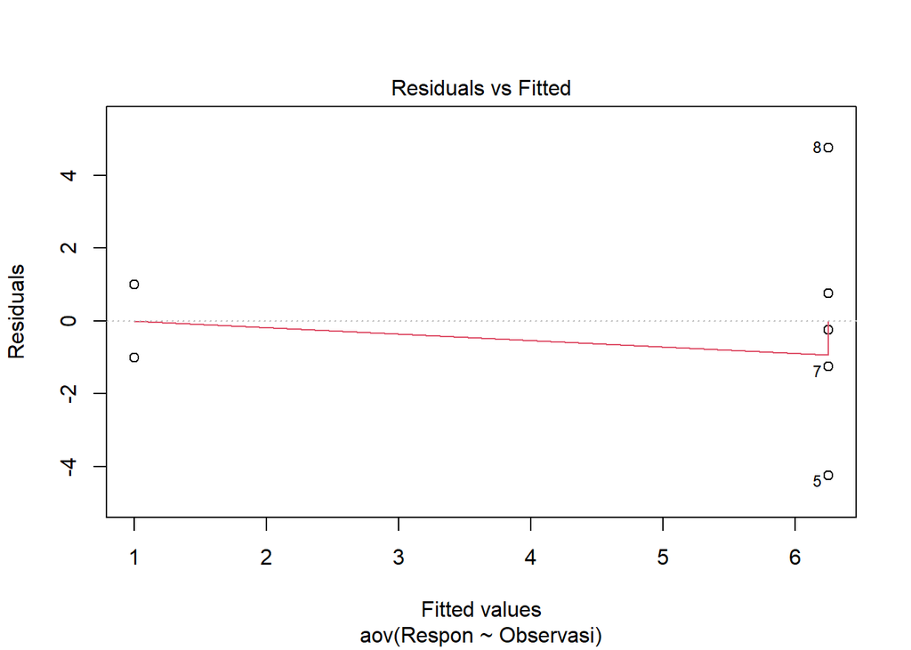

```r
plot(OlahRAL4, which = 1)
```

```r
bartlett.test(Respon ~ Observasi, data = data.menelisik) #Tolak H0
```

```
##
##  Bartlett test of homogeneity of variances
##
## data:  Respon by Observasi
## Bartlett's K-squared = 8.9685, df = 2, p-value = 0.01129
```

Kesimpulan: karena p-value < 0.05 maka tolak H0 atau ragam tak homogen.

### Asumsi amatan saling bebas

H0 : Galat saling bebas  
H1 : Galat tidak saling bebas

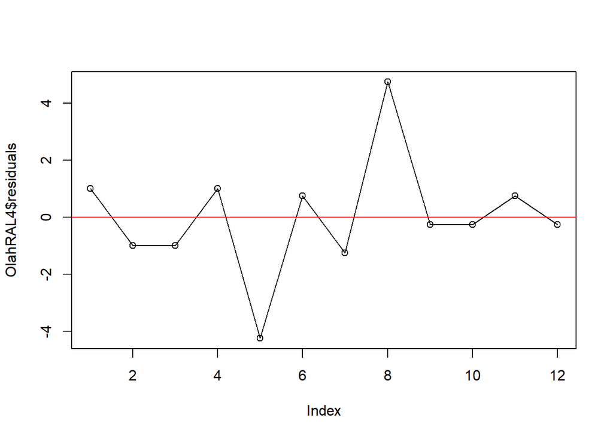

```r
plot(OlahRAL4$residuals, type = "o"); abline(h = 0, col = 'red')
```

```r
runs.test(x = OlahRAL4$residuals) #Tak Tolak H0
```

[output not shown]

Kesimpulan: karena p-value > 0.05 maka tak tolak H0 atau galat saling bebas.

Kemudian, karena terdapat asumsi yang tidak terpenuhi maka perlu dilakukan Uji Kruskal-Wallis sebagai pengganti dari Uji ANOVA satu arah

### Uji Kruskal-Wallis

```r
kruskal.test(Respon ~ Observasi, data = data.menelisik) # Tolak H0
```

```
##
##  Kruskal-Wallis rank sum test
##
## data:  Respon by Observasi
## Kruskal-Wallis chi-squared = 6.7654, df = 2, p-value = 0.03396
```

Kesimpulan: karena p-value < 0.05 maka dapat dikatakan terdapat beda signifikan

## Istirahat

Pemanggilan data:

```r
data.istirahat <- read_xlsx("C:/Users/Agsyan M S/Documents/kuliah IPB/Lain-Lain/Data Bang Adi.xlsx", sheet = 6)
head(data.istirahat)
```

```
## # A tibble: 6 × 4
##   Observasi Ulangan Respon  Rank
##   <chr>       <dbl>  <dbl> <dbl>
## 1 I1              4      8   1
## 2 I1              3      9   2
## 3 I1              1     10   3
## 4 I1              2     12   4
## 5 I2              4     13   5
## 6 I2              2     17   6.5
```

### ANOVA

```r
OlahRAL5 = aov(Respon ~ Observasi, data = data.istirahat)
summary(OlahRAL5) #Beda signifikan
```

```
##             Df Sum Sq Mean Sq F value Pr(>F)
## Observasi    2  742.2   371.1   7.159 0.0138 *
## Residuals    9  466.5    51.8
## ---
## Signif. codes:  0 '***' 0.001 '**' 0.01 '*' 0.05 '.' 0.1 ' ' 1
```

### Asumsi kenormalan

H0 : Galat (eror) menyebar normal  
H1 : Galat tidak menyebar normal

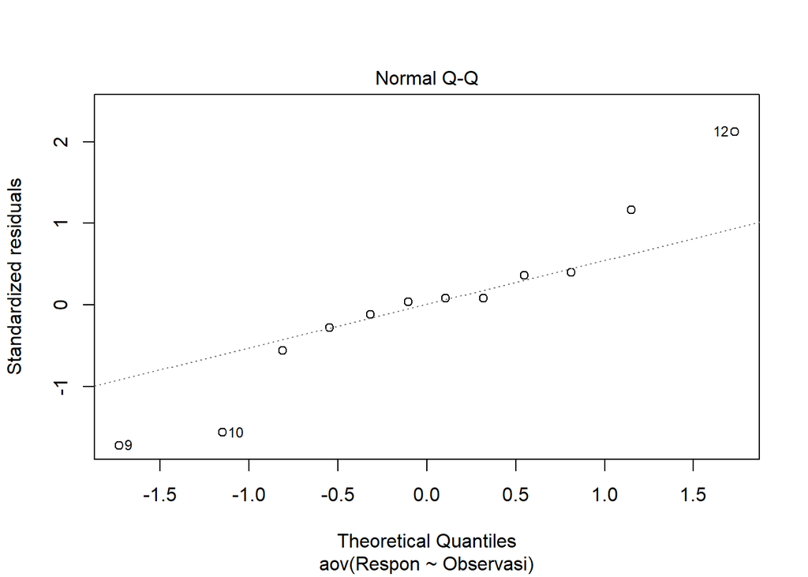

```r
plot(OlahRAL5, which = 2)
```

```r
shapiro.test(OlahRAL5$residuals) #Tak Tolak H0
```

```
##
##  Shapiro-Wilk normality test
##
## data:  OlahRAL5$residuals
## W = 0.94156, p-value = 0.5186
```

Kesimpulan: karena p-value > 0.05 maka tak tolak H0 atau galat menyebar normal.

### Asumsi Kehomogenan Ragam

H0 : Ragam Homogen  
H1 : Ragam Tak Homogen

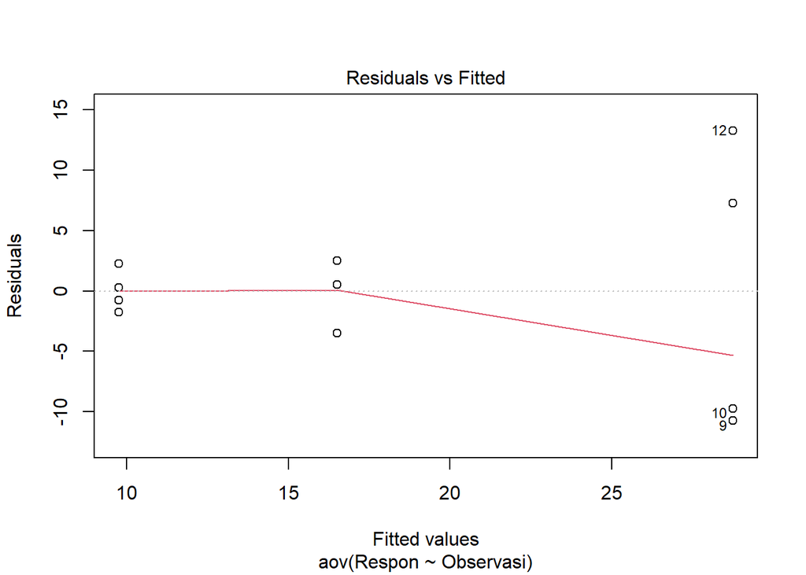

```r
plot(OlahRAL5, which = 1)
```

```r
bartlett.test(Respon ~ Observasi, data = data.istirahat) #Tolak H0
```

```
##
##  Bartlett test of homogeneity of variances
##
## data:  Respon by Observasi
## Bartlett's K-squared = 10.301, df = 2, p-value = 0.005795
```

Kesimpulan: karena p-value < 0.05 maka tolak H0 atau ragam tak homogen

### Asumsi amatan saling bebas

H0 : Galat saling bebas  
H1 : Galat tidak saling bebas

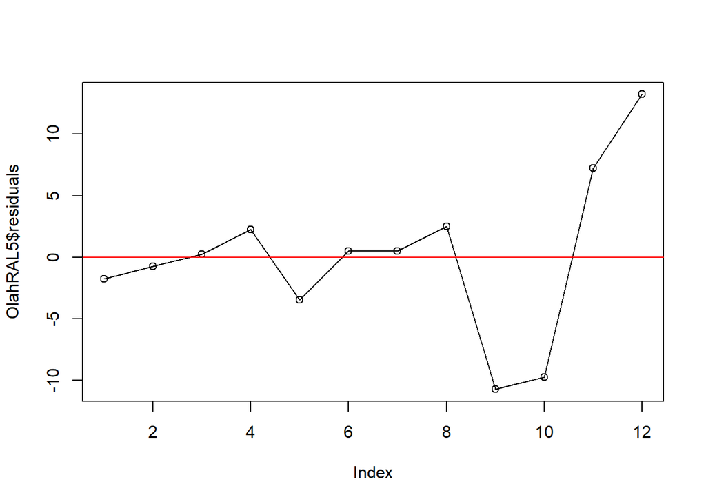

```r
plot(OlahRAL5$residuals, type = "o"); abline(h = 0, col = 'red')
```

```r
runs.test(x = OlahRAL5$residuals) #Tak Tolak H0
```

```
##
##  Runs Test
##
## data:  OlahRAL5$residuals
## statistic = -0.60553, runs = 6, n1 = 6, n2 = 6, n = 12, p-value =
## 0.5448
## alternative hypothesis: nonrandomness
```

Kesimpulan: karena p-value > 0.05 maka tak tolak H0 atau galat saling bebas.

sama seperti perilaku menelisik, terdapat asumsi yang tidak terpenuhi pada ANOVA perilaku istirahat sehingga diperlukan uji Kruskal-Wallis untuk memastikan kesimpulan

### Uji Kruskal-Wallis

```r
kruskal.test(Respon ~ Observasi, data = data.istirahat) # Tolak H0
```

```
##
##  Kruskal-Wallis rank sum test
##
## data:  Respon by Observasi
## Kruskal-Wallis chi-squared = 9.0731, df = 2, p-value = 0.01071
```

Kesimpulan: berdasarkan uji Kruskall-Wallis perilaku istirahat berbeda signifikan

## Eliminasi

Pemanggilan data:

```r
data.eliminasi <- read_xlsx("C:/Users/Agsyan M S/Documents/kuliah IPB/Lain-Lain/Data Bang Adi.xlsx", sheet = 7)
head(data.eliminasi)
```

```
## # A tibble: 6 × 3
##   Observasi Ulangan Respon
##   <chr>       <dbl>  <dbl>
## 1 E1              1      0
## 2 E1              2      0
## 3 E1              3      0
## 4 E1              4      3
## 5 E2              1      1
## 6 E2              2      2
```

### ANOVA

```r
OlahRAL6 = aov(Respon ~ Observasi, data = data.eliminasi)
summary(OlahRAL6) #Tak Beda Signifikan
```

```
##             Df Sum Sq Mean Sq F value Pr(>F)
## Observasi    2  4.167   2.083   0.798   0.48
## Residuals    9 23.500   2.611
```

#### Asumsi kenormalan

H0 : Galat (eror) menyebar normal  
H1 : Galat tidak menyebar normal

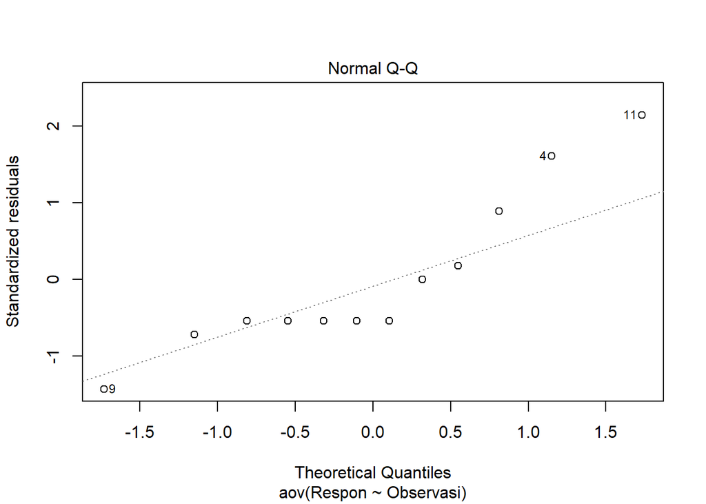

```r
plot(OlahRAL6, which = 2)
```

```r
shapiro.test(OlahRAL6$residuals) #Tak Tolak H0
```

```
##
##  Shapiro-Wilk normality test
##
## data:  OlahRAL6$residuals
## W = 0.86757, p-value = 0.06088
```

Kesimpulan: karena p-valiue > 0.05 maka tak tolak H0 atau galat menyebar normal.

### Asumsi Kehomogenan Ragam

H0 : Ragam Homogen  
H1 : Ragam Tak Homogen

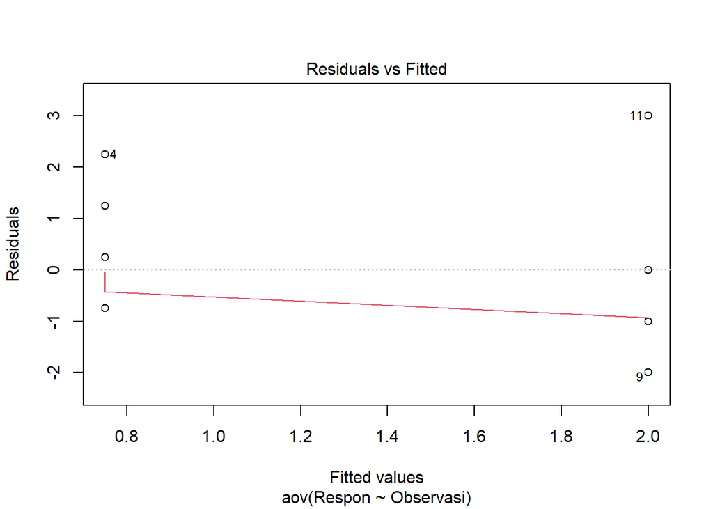

```r
plot(OlahRAL6, which = 1)
```

```r
bartlett.test(Respon ~ Observasi, data = data.eliminasi) #Tak Tolak H0
```

```
##
##  Bartlett test of homogeneity of variances
##
## data:  Respon by Observasi
## Bartlett's K-squared = 1.6068, df = 2, p-value = 0.4478
```

Kesimpulan: karena p-value > 0.05 maka tak tolak H0 atau ragam homogen

#### Asumsi amatan saling bebas

H0 : Galat saling bebas  
H1 : Galat tidak saling bebas

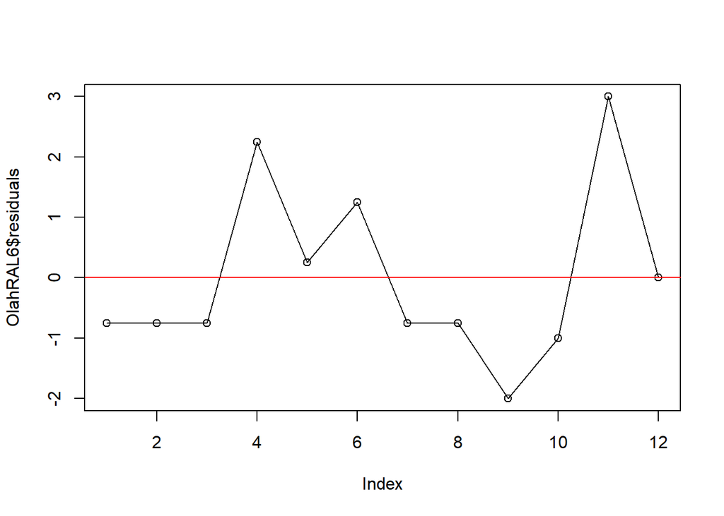

```r
plot(OlahRAL6$residuals, type = "o"); abline(h = 0, col = 'red')
```

```r
runs.test(x = OlahRAL6$residuals) #Tak Tolak H0
```

```
##
##  Runs Test
##
## data:  OlahRAL6$residuals
## statistic = -1.2111, runs = 5, n1 = 6, n2 = 6, n = 12, p-value = 0.2259
## alternative hypothesis: nonrandomness
```

Kesimpulan: karena p-value > 0.05 maka tak tolak H0 atau galat saling bebas.

## Perilaku Sosial

Pemanggilan data:

```r
data.perilaku.s <- read_xlsx("C:/Users/Agsyan M S/Documents/kuliah IPB/Lain-Lain/Data Bang Adi.xlsx", sheet = 8)
head(data.perilaku.s)
```

```
## # A tibble: 6 × 3
##   Observasi Ulangan Respon
##   <chr>       <dbl>  <dbl>
## 1 PS1             1      0
## 2 PS1             2      7
## 3 PS1             3      6
## 4 PS1             4      4
## 5 PS2             1      2
## 6 PS2             2      0
```

### ANOVA

```r
OlahRAL7 = aov(Respon ~ Observasi, data = data.perilaku.s)
summary(OlahRAL7) #Beda Signifikan
```

```
##             Df Sum Sq Mean Sq F value Pr(>F)
## Observasi    2  37.17  18.583   5.268 0.0306 *
## Residuals    9  31.75   3.528
## ---
## Signif. codes:  0 '***' 0.001 '**' 0.01 '*' 0.05 '.' 0.1 ' ' 1
```

### Asumsi kenormalan

H0 : Galat (eror) menyebar normal  
H1 : Galat tidak menyebar normal

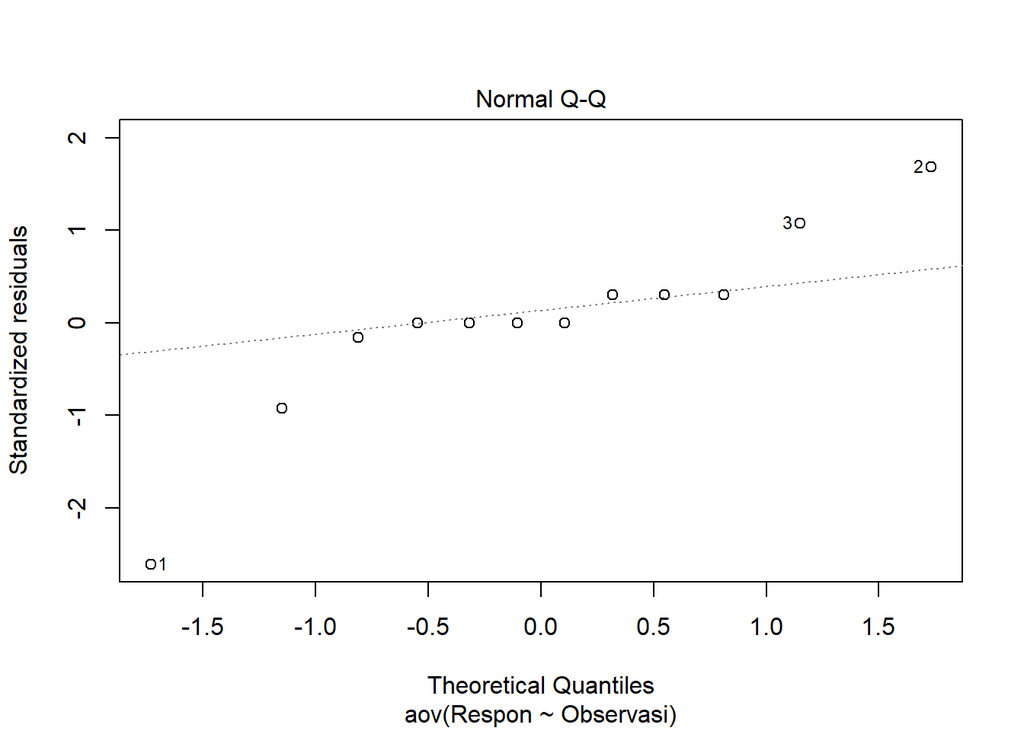

```r
plot(OlahRAL7, which = 2)
```

```r
shapiro.test(OlahRAL7$residuals) #Tolak H0
```

```
##
##  Shapiro-Wilk normality test
##
## data:  OlahRAL7$residuals
## W = 0.8564, p-value = 0.04407
```

Kesimpulan: karena p-value < 0.05 maka tolak H0 atau galat tidak menyebar normal.

### Asumsi Kehomogenan Ragam

H0 : Ragam Homogen  
H1 : Ragam Tak Homogen

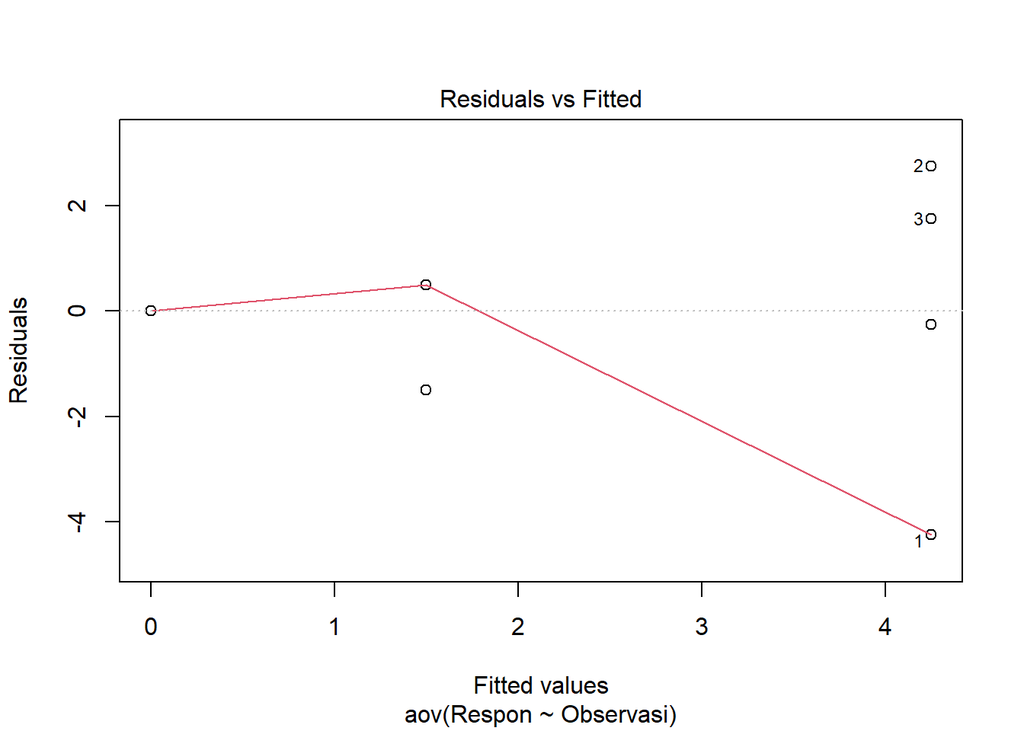

```r
plot(OlahRAL7, which = 1)
```

```r
bartlett.test(Respon ~ Observasi, data = data.perilaku.s) #Tolak H0
```

```
##
##  Bartlett test of homogeneity of variances
##
## data:  Respon by Observasi
## Bartlett's K-squared = Inf, df = 2, p-value < 2.2e-16
```

Kesimpulan: karena p-value < 0.05 maka tolak H0 atau ragam tak homogen

### Asumsi amatan saling bebas

H0 : Galat saling bebas  
H1 : Galat tidak saling bebas

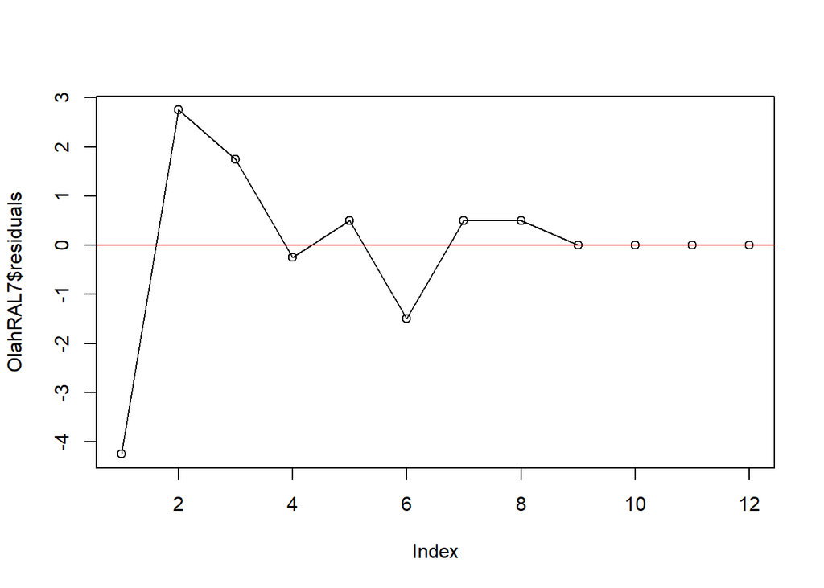

```r
plot(OlahRAL7$residuals, type = "o"); abline(h = 0, col = 'red')
```

```r
runs.test(x = OlahRAL7$residuals) #Tak Tolak H0
```

```
##
##  Runs Test
##
## data:  OlahRAL7$residuals
## statistic = 1.0299, runs = 6, n1 = 5, n2 = 3, n = 8, p-value = 0.3031
## alternative hypothesis: nonrandomness
```

Kesimpulan: karena p-value > 0.05 maka tak tolak H0 atau galat saling bebas

Ternyata Perilaku sosial walaupun berdasarkan Uji ANOVA menghasilkan hasil yang beda signifikan. Akan tetapi, terdapat dua asumsi yang tidak terpenuhi sehingga terlalu riskan untuk menerima uji ANOVA sehingga diperlukan uji Kruskal-Wallis.

### Uji Kruskal-Wallis

```r
kruskal.test(Respon ~ Observasi, data = data.perilaku.s) #Tak Tolak H0
```

```
##
##  Kruskal-Wallis rank sum test
##
## data:  Respon by Observasi
## Kruskal-Wallis chi-squared = 5.7115, df = 2, p-value = 0.05751
```

Hasil Uji Kruskal-Wallis menunjukkan bahwa tidak terdapat beda yang signifikan terhadap perilaku sosial yang terlihat dari p-value > 0.05. Kseimpulannya kita memilih hasil uji Kruskal-Wallis dibanding ANOVA untuk perilaku sosial.

## Lokomosi

Pemanggilan data:

```r
data.lokomosi <- read_xlsx("C:/Users/Agsyan M S/Documents/kuliah IPB/Lain-Lain/Data Bang Adi.xlsx", sheet = 9)
head(data.lokomosi)
```

```
## # A tibble: 6 × 3
##   Observasi Ulangan Respon
##   <chr>       <dbl>  <dbl>
## 1 L1              1     46
## 2 L1              2     40
## 3 L1              3     49
## 4 L1              4     42
## 5 L2              1     41
## 6 L2              2     42
```

### ANOVA

```r
OlahRAL8 = aov(Respon ~ Observasi, data = data.lokomosi)
summary(OlahRAL8) #Beda Signifikan
```

```
##             Df Sum Sq Mean Sq F value   Pr(>F)
## Observasi    2 1772.2   886.1      26 0.000182 ***
## Residuals    9  306.8    34.1
## ---
## Signif. codes:  0 '***' 0.001 '**' 0.01 '*' 0.05 '.' 0.1 ' ' 1
```

### Asumsi kenormalan

H0 : Galat (eror) menyebar normal  
H1 : Galat tidak menyebar normal

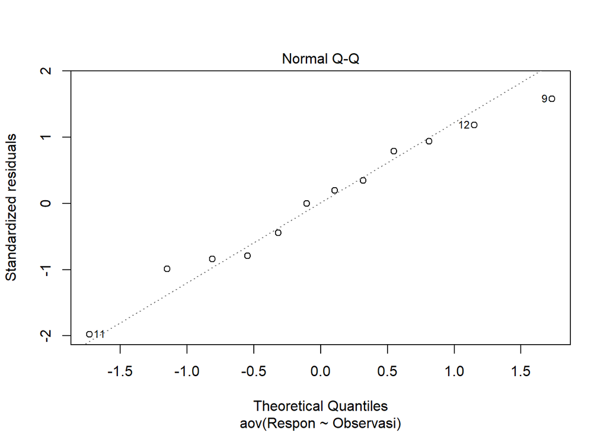

```r
plot(OlahRAL8, which = 2)
```

```r
shapiro.test(OlahRAL8$residuals) #Tak Tolak H0
```

```
##
##  Shapiro-Wilk normality test
##
## data:  OlahRAL8$residuals
## W = 0.975, p-value = 0.9555
```

Kesimpulan: karena p-value > 0.05 maka tak tolak H0 atau galat menyebar normal.

### Asumsi Kehomogenan Ragam

H0 : Ragam Homogen  
H1 : Ragam Tak Homogen

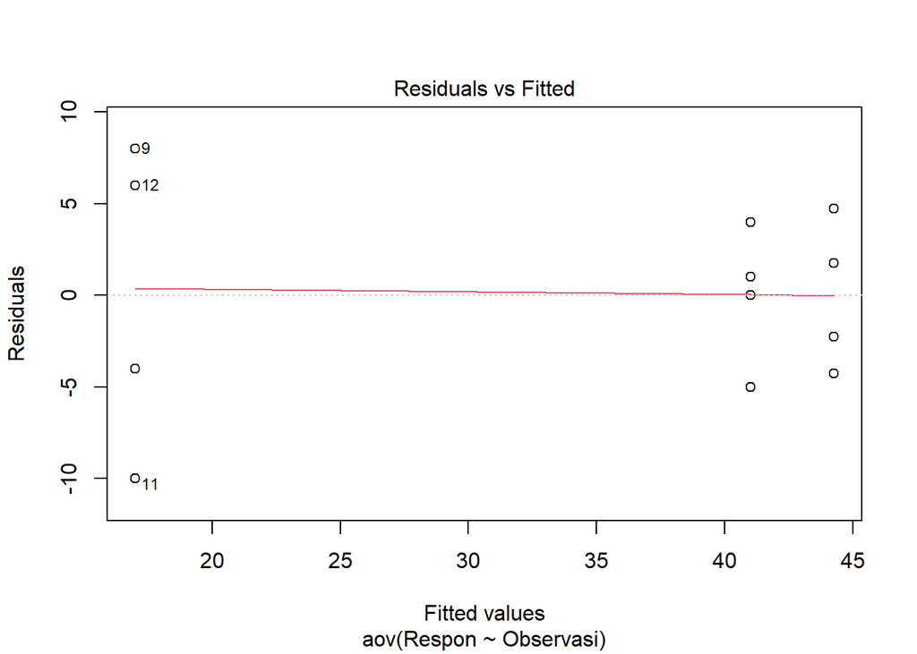

```r
plot(OlahRAL8, which = 1)
```

```r
bartlett.test(Respon ~ Observasi, data = data.lokomosi) #Tak Tolak H0
```

```
##
##  Bartlett test of homogeneity of variances
##
## data:  Respon by Observasi
## Bartlett's K-squared = 2.3062, df = 2, p-value = 0.3157
```

Kesimpulan: karena p-value > 0.05 maka tak tolak H0 atau ragam homogen.

### Asumsi amatan saling bebas

H0 : Galat saling bebas  
H1 : Galat tidak saling bebas

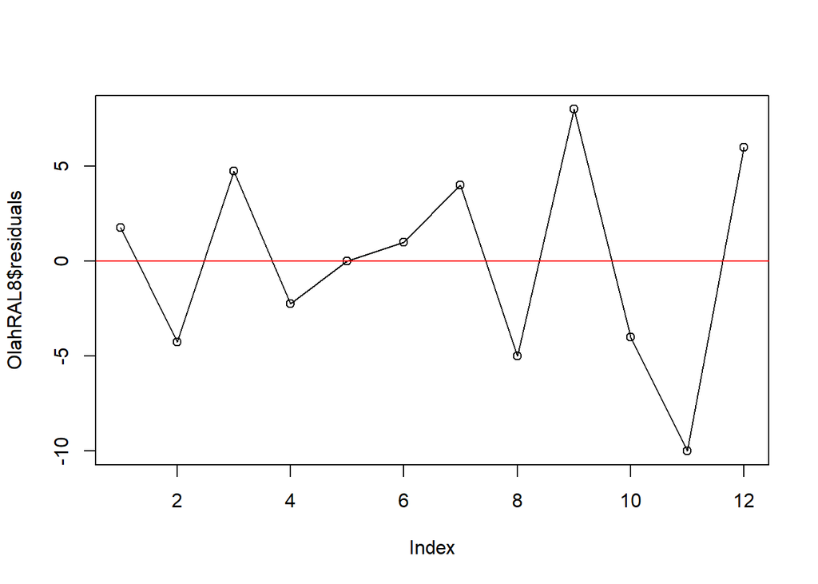

```r
plot(OlahRAL8$residuals, type = "o"); abline(h = 0, col = 'red')
```

```r
runs.test(x = OlahRAL8$residuals) #Tak Tolak H0
```

```
##
##  Runs Test
##
## data:  OlahRAL8$residuals
## statistic = 1.2111, runs = 9, n1 = 6, n2 = 6, n = 12, p-value = 0.2259
## alternative hypothesis: nonrandomness
```

Kesimpulan: karena p-value > 0.05 maka tak tolak H0 atau galat saling bebas.